# Import Libraries

Libraries/packages for data manipulation, modeling, metrics calculation, fairness evaluation, explainability, and visualization.

```python
import pandas as pd
import numpy as np

from sklearn.model_selection import train_test_split
from sklearn.preprocessing import StandardScaler, LabelEncoder
from sklearn.linear_model import LogisticRegression
from sklearn.metrics import accuracy_score, precision_score, recall_score, roc_auc_score

from fairlearn.metrics import MetricFrame, selection_rate, true_positive_rate, false_positive_rate
from fairlearn.reductions import ExponentiatedGradient, DemographicParity

import lime
import lime.lime_tabular
from IPython.display import display, HTML

import matplotlib.pyplot as plt
```

# Load Dataset

The UCI Adult Income dataset is loaded using Fairlearn and converted into a pandas DataFrame.

```python
from fairlearn.datasets import fetch_adult

# Load dataset
data = fetch_adult(as_frame=True)
df = data.frame.copy()
df.head()
```

|  | age | workclass | fnlwgt | education | education-num | marital-status | occupation | relationship | race | sex | capital-gain | capital-loss | hours-per-week | native-country | class |
| --- | --- | --- | --- | --- | --- | --- | --- | --- | --- | --- | --- | --- | --- | --- | --- |
| 0 | 25 | Private | 226802 | 11th | 7 | Never-married | Machine-op-inspct | Own-child | Black | Male | 0 | 0 | 40 | United-States | <=50K |
| 1 | 38 | Private | 89814 | HS-grad | 9 | Married-civ-spouse | Farming-fishing | Husband | White | Male | 0 | 0 | 50 | United-States | <=50K |
| 2 | 28 | Local-gov | 336951 | Assoc-acdm | 12 | Married-civ-spouse | Protective-serv | Husband | White | Male | 0 | 0 | 40 | United-States | >50K |
| 3 | 44 | Private | 160323 | Some-college | 10 | Married-civ-spouse | Machine-op-inspct | Husband | Black | Male | 7688 | 0 | 40 | United-States | >50K |
| 4 | 18 | NaN | 103497 | Some-college | 10 | Never-married | NaN | Own-child | White | Female | 0 | 0 | 30 | United-States | <=50K |

# Preprocessing and Data Splitting

Features and target are separated, the sensitive attribute is identified and removed from the features, categorical variables are label-encoded, the dataset is split into training and test sets, and numeric features are standardized.

```python
# Features and target
X = df.drop(columns=["class"])
y = df["class"].apply(lambda x: 1 if x==">50K" else 0)  # Binary encoding

# Sensitive attribute
sensitive_feature = X["sex"]
X = X.drop(columns=["sex"])  # Remove sensitive attribute

# Label encode categorical variables
categorical_cols = X.select_dtypes(include='category').columns
label_encoders = {}

for col in categorical_cols:
    le = LabelEncoder()
    X[col] = le.fit_transform(X[col])
    label_encoders[col] = le  # Save encoder for mapping back if needed

# Split dataset
X_train, X_test, y_train, y_test, s_train, s_test = train_test_split(
    X, y, sensitive_feature, test_size=0.3, random_state=42, stratify=y
)

# Standardize numeric features
numeric_cols = X_train.select_dtypes(include=np.number).columns
scaler = StandardScaler()
X_train[numeric_cols] = scaler.fit_transform(X_train[numeric_cols])
X_test[numeric_cols] = scaler.transform(X_test[numeric_cols])
```

```python
X_train
```

|  | age | workclass | fnlwgt | education | education-num | marital-status | occupation | relationship | race | capital-gain | capital-loss | hours-per-week | native-country |
| --- | --- | --- | --- | --- | --- | --- | --- | --- | --- | --- | --- | --- | --- |
| 38865 | -1.291271 | -0.237433 | 1.214724 | 0.185970 | -0.418928 | 0.911577 | 1.522307 | -0.275751 | 0.388900 | -0.144333 | -0.219417 | 1.569855 | 0.250538 |
| 17212 | -1.437112 | 2.914302 | -1.310118 | 1.222084 | -0.030135 | 0.911577 | 1.753595 | 0.973606 | 0.388900 | -0.144333 | -0.219417 | -2.451436 | 0.250538 |
| 9312 | -0.489145 | 2.914302 | 1.437669 | 0.185970 | -0.418928 | -0.413392 | 1.753595 | -0.900429 | -1.983708 | -0.144333 | -0.219417 | 0.363468 | 0.250538 |
| 15512 | -0.270383 | -0.237433 | 0.793401 | -0.332087 | 1.136241 | -1.738361 | 1.522307 | -0.275751 | 0.388900 | -0.144333 | -0.219417 | -0.038662 | 0.250538 |
| 23576 | -1.291271 | -0.237433 | -0.142290 | -0.850144 | 0.747449 | 0.911577 | -1.484443 | 0.973606 | 0.388900 | -0.144333 | -0.219417 | -0.440791 | 0.250538 |
| ... | ... | ... | ... | ... | ... | ... | ... | ... | ... | ... | ... | ... | ... |
| 16180 | -0.853747 | -0.237433 | -1.497409 | 0.444998 | 1.525033 | -0.413392 | -1.484443 | 2.222963 | 0.388900 | -0.144333 | -0.219417 | -1.647178 | 0.250538 |
| 42096 | 1.042186 | -0.237433 | -0.113799 | -0.332087 | 1.136241 | -0.413392 | -1.021866 | -0.900429 | 0.388900 | -0.144333 | -0.219417 | 0.283042 | 0.250538 |
| 29457 | 0.312981 | -0.237433 | -0.378570 | 0.185970 | -0.418928 | -0.413392 | -1.021866 | -0.900429 | 0.388900 | -0.144333 | -0.219417 | 0.122190 | 0.250538 |
| 20602 | -0.489145 | -0.237433 | -1.043937 | 0.185970 | -0.418928 | -0.413392 | -1.484443 | -0.900429 | 0.388900 | -0.144333 | -0.219417 | -0.038662 | 0.250538 |
| 4610 | 0.458822 | 2.914302 | 0.638183 | -0.332087 | 1.136241 | -0.413392 | 1.753595 | -0.900429 | -1.983708 | -0.144333 | -0.219417 | 0.363468 | 0.250538 |

34189 rows × 13 columns

# Train Logistic Regression

A logistic regression classifier is trained on the training data and evaluated on the test data using accuracy, precision, recall, and AUC metrics.

```python
clf = LogisticRegression(max_iter=500, solver="lbfgs")
clf.fit(X_train, y_train)

print("Actual iterations:", clf.n_iter_)

y_pred = clf.predict(X_test)
y_proba = clf.predict_proba(X_test)[:,1]

accuracy = accuracy_score(y_test, y_pred)
precision = precision_score(y_test, y_pred)
recall = recall_score(y_test, y_pred)
auc = roc_auc_score(y_test, y_proba)

accuracy, precision, recall, auc
```

```
Actual iterations: [11]
```

```
(0.8248822766668942,
 0.7214891611687088,
 0.43667997718197377,
 0.8496348209999329)
```

# Fairness Metrics Evaluation

Fairness metrics including demographic parity, equal opportunity, and equalized odds are computed for each group based on the sensitive attribute using Fairlearn.

```python
metrics = {
    "accuracy": accuracy_score,
    "selection_rate": selection_rate,
    "true_positive_rate": true_positive_rate,
    "false_positive_rate": false_positive_rate
}

metric_frame = MetricFrame(metrics=metrics, y_true=y_test, y_pred=y_pred, sensitive_features=s_test)
metric_frame.by_group
```

| sex | accuracy | selection_rate | true_positive_rate | false_positive_rate |
| --- | --- | --- | --- | --- |
| Female | 0.891497 | 0.056002 | 0.269439 | 0.028578 |
| Male | 0.791854 | 0.188853 | 0.467999 | 0.068391 |

# Transparency Analysis with LIME

```python
explainer = lime.lime_tabular.LimeTabularExplainer(
    training_data=np.array(X_train),
    feature_names=X_train.columns,
    class_names=["<=50K", ">50K"],
    mode="classification"
)

idxs_to_explain = [0]
for idx in idxs_to_explain:
    exp = explainer.explain_instance(
        data_row=X_test.iloc[idx],
        predict_fn=clf.predict_proba
    )
    print(f"Explanation for test instance {idx}:")
    display(HTML(exp.as_html()))
```

[output not shown]

```
Explanation for test instance 0:
```

# Fairness Intervention with ExponentiatedGradient

The ExponentiatedGradient algorithm with a demographic parity constraint is applied to mitigate bias. Metrics are recomputed for the adjusted model predictions.

```python
constraint = DemographicParity()
exp_grad = ExponentiatedGradient(LogisticRegression(max_iter=500, solver="lbfgs"), constraints=constraint)
exp_grad.fit(X_train, y_train, sensitive_features=s_train)

y_pred_fg = exp_grad.predict(X_test)

metric_frame_fg = MetricFrame(metrics=metrics, y_true=y_test, y_pred=y_pred_fg, sensitive_features=s_test)
metric_frame_fg.by_group
```

| sex | accuracy | selection_rate | true_positive_rate | false_positive_rate |
| --- | --- | --- | --- | --- |
| Female | 0.882026 | 0.114474 | 0.484629 | 0.066914 |
| Male | 0.769804 | 0.124745 | 0.325093 | 0.038287 |

# Visualize Fairness Improvement

Selection rates before and after the fairness intervention are visualized to show changes in demographic parity.

```
        Baseline  After Intervention
sex
Female  0.056002            0.114474
Male    0.188853            0.124745
```

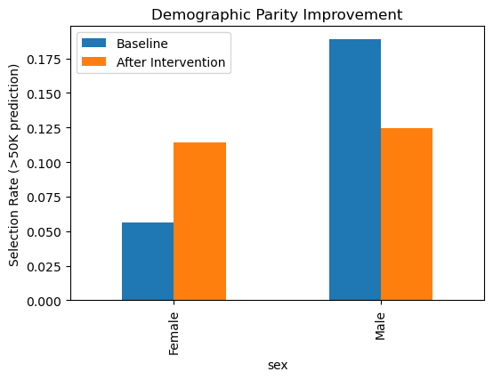

```python
df_metrics = pd.DataFrame({
    "Baseline": metric_frame.by_group["selection_rate"],
    "After Intervention": metric_frame_fg.by_group["selection_rate"]
})

print(df_metrics)

df_metrics.plot(kind="bar", figsize=(6,4))
plt.ylabel("Selection Rate (>50K prediction)")
plt.title("Demographic Parity Improvement")
plt.show()
```